# Blog

# Further reads

- [Create a grid by Urban data palette](https://urbandatapalette.com/post/2021-08-tessellation-sf/)
- [Thematic mapping in Mapping in R](https://map-rfun.library.duke.edu/032_thematic_mapping_geom_sf.html)
- [Mapping in R workshop](https://geanders.github.io/navy_public_health/index.html#prerequisites)
- [ggplot2 color scales](https://ggplot2-book.org/scale-colour.html)
- [ggplot2 legend keys](https://www.rusersplace.com/2022/08/21/index.zh-cn/images/FabxzmnX0AEwau0.jpg)

# Export

# ~~~~~~~~~~~~~

# 5.May: githubpage

# Intro

The goal of this post is to:

- Create a github page for a presentation

For the example, a xaringan presentation is to be deployed as github page for easy access

## Repository

You need to have a repository, if you are first time creating a reposotory, here are some [instructions](https://miriamll.github.io/git_pres/GitGithubZenodo#11)

## Settings

Go to your repository, select **settings**

In the right side of the screen select **pages**

[figure not shown]

## Github actions

Look for build and deployment and in source, move from GitHub Actions to **Deploy from branch**

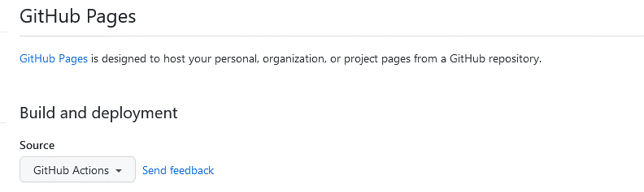

## Branch

The branch depends where the **html** file is, here I have it in the **master** branch

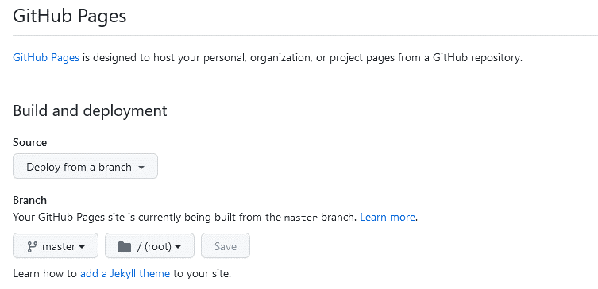

This would depend where you have your **html** file, but here I have it in the **master**

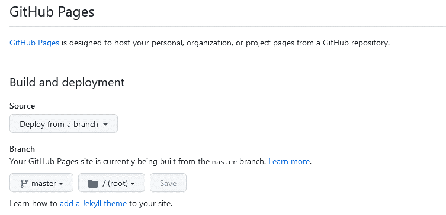

## Reload

If everything went well **Your site is alive at** will appear

[figure not shown]

## Diferent slides

To access specific slides from different presentations, add the html name at the end of the site.

For example:

```r
https://miriamll.github.io/R_intro/IntroToR_0604.html#1
```

## To pdf

The slides can also be converted to pdf

Install package using **install.packages(“renderthis”)**

```r
library(renderthis)
```

```r
to_pdf(from="https://miriamll.github.io/R_intro/DataWrangling_1205.html")
```

## Further reading

- [Github Pages](https://pages.github.com/)
- [renderthis](https://jhelvy.github.io/renderthis/articles/renderthis.html)

# ~~~~~~~~~~~~~

# 6.June: gganimate

# Intro

How to create a map an animation using gganimate

## 1. Getting ready

Load and/or install the following packages:

```r
library(here)
library(tidyverse)
```

## 2. Load data

```r
library(sula)
```

```r
Example<-GPS_01
```

## 3. Mark beggining

Mark a day zero to begging the animation, and the sequence to use

```r
first(Example$DateGMT)
```

```
## [1] "02/11/2017"
```

```r
Example$date_diff <- as.Date(as.character(Example$tStamp),
                             format="%Y-%m-%d")-
  as.Date(as.character('2017-11-02'),
          format="%Y-%m-%d")
```

Create number sequence for animation

```r
Example<-Example %>%
  group_by(IDs) %>%
  mutate(Secuencia = row_number())
```

## 4. Create map for reference

For creating maps, the package **sf** is to be called.

```r
library(sf)
```

Now load your data, here I am giving my directory, you should use the one on your computer.

To dowload the shapefile from Chile you can use this [this link](https://github.com/MiriamLL/miriamlerma_/blob/main/_posts/2023-06-01-gganimate/CHL_adm1.shp), this shapefile comes from the [DIVA-GIS](https://www.diva-gis.org/datadown)

```r
Country<-st_read(paste0(Directory,MyShapefileName))
```

## 5. Plot

Plot the area of interest

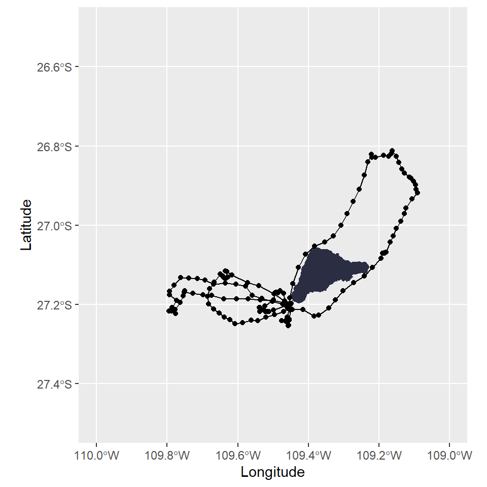

```r
My_map<-ggplot(data=Example)  +
  geom_sf(data = Country,colour = "#edf2f4", fill = "#2b2d42",)+
  geom_point(data=Example,aes(x = Longitude, y=Latitude))+
  geom_path(data=Example,aes(x = Longitude, y=Latitude))+
  coord_sf(xlim = c(-110,-109), ylim = c(-27.5,-26.5))
My_map
```

## 6. Modify map to taste

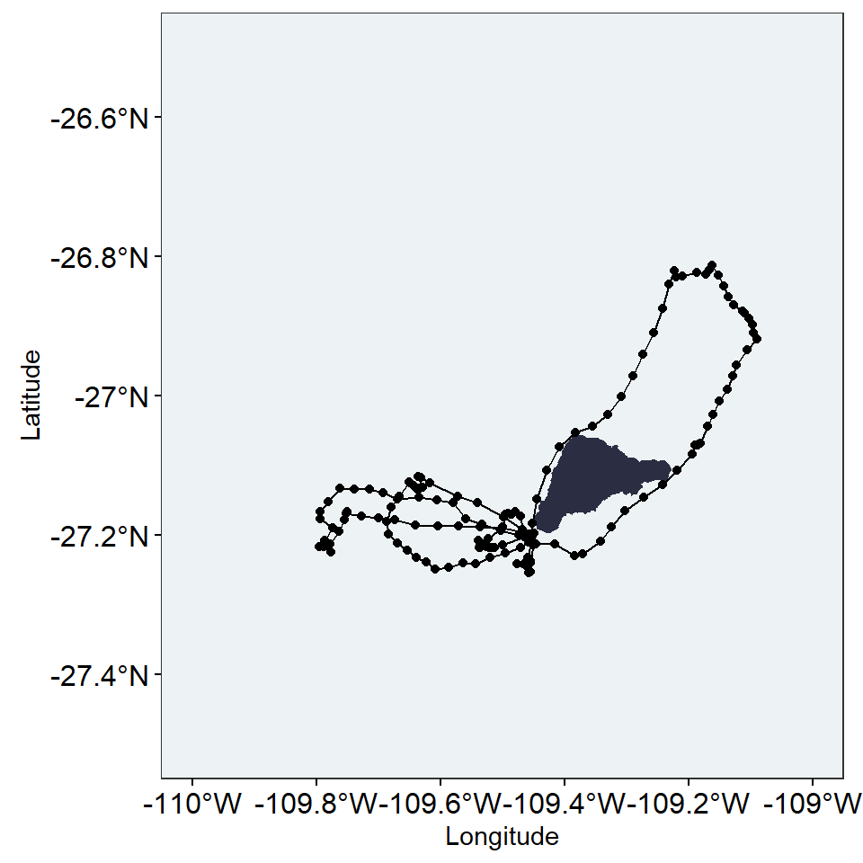

```r
My_map<-My_map+
 theme_bw()+

  theme(
    panel.grid.major = element_blank(),
    panel.grid.minor = element_blank(),
    panel.background = element_rect(fill = '#edf2f4'),

    axis.text.x =  element_text(size=12,color = "black"),
    axis.text.y =  element_text(size=12,color = "black"),

    axis.ticks.x = element_line(color = "black"),
    axis.ticks.y = element_line(color = "black"),

    title = element_text(colour = "black"),
    legend.position = "none")+

    scale_x_continuous(labels = function(x) paste0(x, '\u00B0', "W")) +
    scale_y_continuous(labels = function(x) paste0(x, '\u00B0', "N"))
My_map
```

## 7. Animate

To animate this plot, we will use the package **gganimate**

```r
library(gganimate)
```

Because animations might take some time, I like to use the package **beepr** to let me know when the animation is ready

```r
library(beepr)
```

**transition_reveal** leaves the track on the back ground so you can keep record where it was

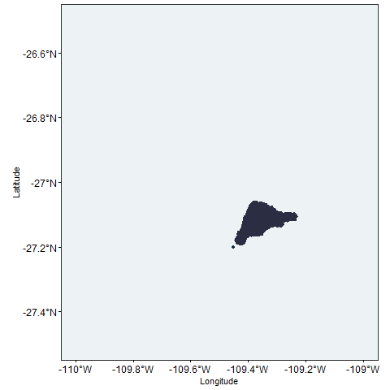

```r
My_animation<-ggplot(data=Example)  +
  geom_sf(data = Country,colour = "#edf2f4", fill = "#2b2d42",)+
  geom_point(data=Example,aes(x = Longitude, y=Latitude, colour = tStamp))+
  geom_path(data=Example,aes(x = Longitude, y=Latitude))+
  coord_sf(xlim = c(-110,-109), ylim = c(-27.5,-26.5))+

  theme_bw()+

  theme(
    panel.grid.major = element_blank(),
    panel.grid.minor = element_blank(),
    panel.background = element_rect(fill = '#edf2f4'),

    axis.text.x =  element_text(size=12,color = "black"),
    axis.text.y =  element_text(size=12,color = "black"),

    axis.ticks.x = element_line(color = "black"),
    axis.ticks.y = element_line(color = "black"),

    title = element_text(colour = "black"),
    legend.position = "none")+

    scale_x_continuous(labels = function(x) paste0(x, '\u00B0', "W")) +
    scale_y_continuous(labels = function(x) paste0(x, '\u00B0', "N")) +

  transition_reveal(along=tStamp) +
  shadow_trail(distance = 0.01,
               alpha = 0.5,
               shape = 1)
My_animation
```

Other arguments are:  
**transition_time** use the information for the transition is **labs** shows the title with time so you can use as a reference  
**shadow_wake** is the wake behind the points [read more here](https://goodekat.github.io/presentations/2019-isugg-gganimate-spooky/slides.html#48)

## 8. Export

The package **animation** allows to save the animation as a file

```r
library(animation)
```

To export, you can save the animation as gif

```r
# anim_save("animation.gif",My_animation)
# beep(sound=1,expr=NULL)
```

Or transform from gif to mp4 using the package **av**

```r
library(av)
# av::av_encode_video("animation.gif",
#                     framerate = 5 ,
#                     output = 'animation.mp4')
# beep(sound=1,expr=NULL)
```

# Further reading

- [A Grammar of Animated Graphics](https://gganimate.com/)
- [Step by step with Katherine Goode](https://goodekat.github.io/presentations/2019-isugg-gganimate-spooky/slides.html#1)
- [Step by step with Ander Fernandez](https://anderfernandez.com/en/blog/how-to-create-animations-in-r-with-gganimate/)
- [Migration animated](https://www.climatecentral.org/news/map-animal-migration-climate-change-20646)

# ~~~~~~~~~~~~~

# 7.July: custom points

# Intro

Customize your plot using different sizes, shapes and colors in the points of your figures.

# Data

Load or install the package **SeaDens**

```r
devtools::install_github("MiriamLL/SeaDens")
```

```r
library(SeaDens)
```

Load data

The package contains data from a random generated density data frame.

```r
density_df<-density_df
```

The data frame contains latitude, longitude and density estimations.

To check the data lets use **ggplot**.

First call the library.

```r
library(ggplot2)
```

Then check the data contained on the data frame.

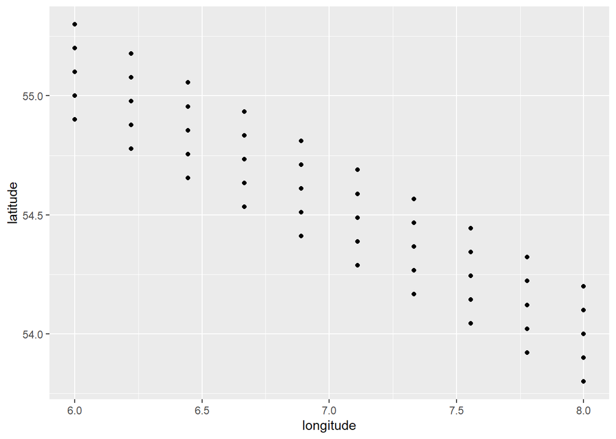

```r
ggplot()+
  geom_point(data=density_df,
          aes(x = longitude,
              y= latitude))
```

Each of the dots contains density data, to check the values you can use the function **range** for the minimal and maximal values.

```r
range(density_df$densities)
```

```
## [1] 0.00000 4.94831
```

## Classify

Based on the range of the densities, define how many classes you want to use and where the cuts will be made.

```r
class0<-0
class1<-1
class2<-2.5
class3<-5
```

Using the function **mutate** from the package **tidyverse** add a new column with a classification.  
Note that using alphanumerical order is important for the order in the legend.

```r
library(tidyverse)
```

```r
density_df<-density_df %>%
    mutate(density_class = case_when(
      densities ==  class0 ~ as.character("group0"),
      densities >=  class0 & densities <=  class1 ~ as.character("group1"),
      densities >=  class1 & densities <=  class2 ~ as.character("group2"),
      densities >=  class2 & densities <=  class3 ~ as.character("group3"),
      densities >=  class3 ~ as.character("group4"),
      TRUE~"U"))
```

Check number of observations to make sure your classification was working and that you have at least one value per group.

```r
density_df %>%
  group_by(density_class)%>%
  tally()
```

```
## # A tibble: 4 × 2
##   density_class     n
##   <chr>         <int>
## 1 group0           25
## 2 group1            4
## 3 group2            5
## 4 group3           16
```

# Define

To define the sizes, numbers can be used.

```r
density_sizes<-c("group0"=0.5, "group1"=1,"group2"=2, "group3"=3, "group4"=5)
```

To define the text on the labels, characters can be used.

```r
density_labels<-c('0','> 0-1','> 1-2.5','> 2.5-5','> 5')
```

```r
class(density_labels)
```

```r
density_shapes<-c("group0"=3, "group1"=21,"group2"=21, "group3"=21, "group4"=21)
```

For reference on the shape types:

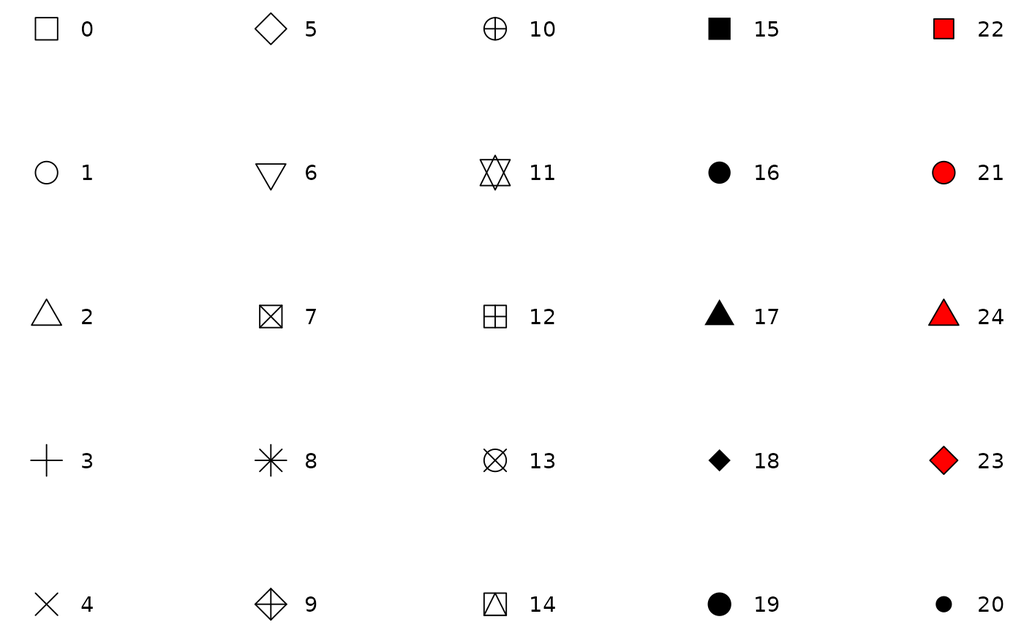

## Base plot

To visualize your data, create a base plot with defined shape, size and labels.  
To define the shape and size, the argument was added inside the **aes**.  
To assign the values and labels, fill the arguments **scale_shape_manual** and **scale_size_manual**.

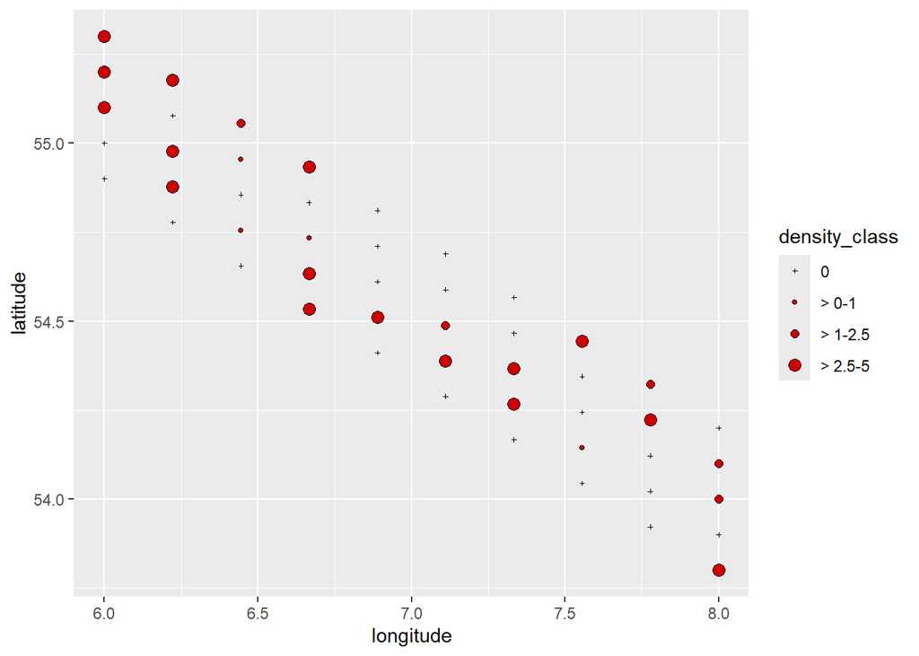

```r
ggplot()+
  geom_point(data=density_df,
          aes(x = longitude,
              y= latitude,
              shape = density_class,
              size= density_class),
              fill= "#d00000")+

  scale_shape_manual(values = density_shapes,labels=density_labels)+
  scale_size_manual(values =  density_sizes,labels=density_labels)
```

## Add map

Since we need reference map, the package **sf** contains the function **geom_sf** that allows plotting shapefiles, and the package **GermanNorthSea** contains shapefiles from the North Sea readily available for use.

Call (or install) the packages

```r
library(sf)
library(GermanNorthSea)
```

Some parameters need to be adjusted first, such as which CRS to use, and the limits on the map.  
For more details go to: [Mapping in R](https://www.miriam-lerma.com/posts/2023-03-04-mapping-in-r/) and [GermanNorthSea](https://www.miriam-lerma.com/posts/2023-06-02-germannorthsea/)

Here the parameters define that we are going to use CRS 4326, color the land in yellow and the water in blue, and define the coordinates to plot.

```r
my_CRS<-4326
Europa<-sf::st_transform(German_land, my_CRS)
EEZ<-sf::st_transform(German_EEZ, my_CRS)
color_land='#f7bf54'
color_water='#3668b4'
xval<-c(3,9)
yval<-c(53,56)
```

Create a base map.

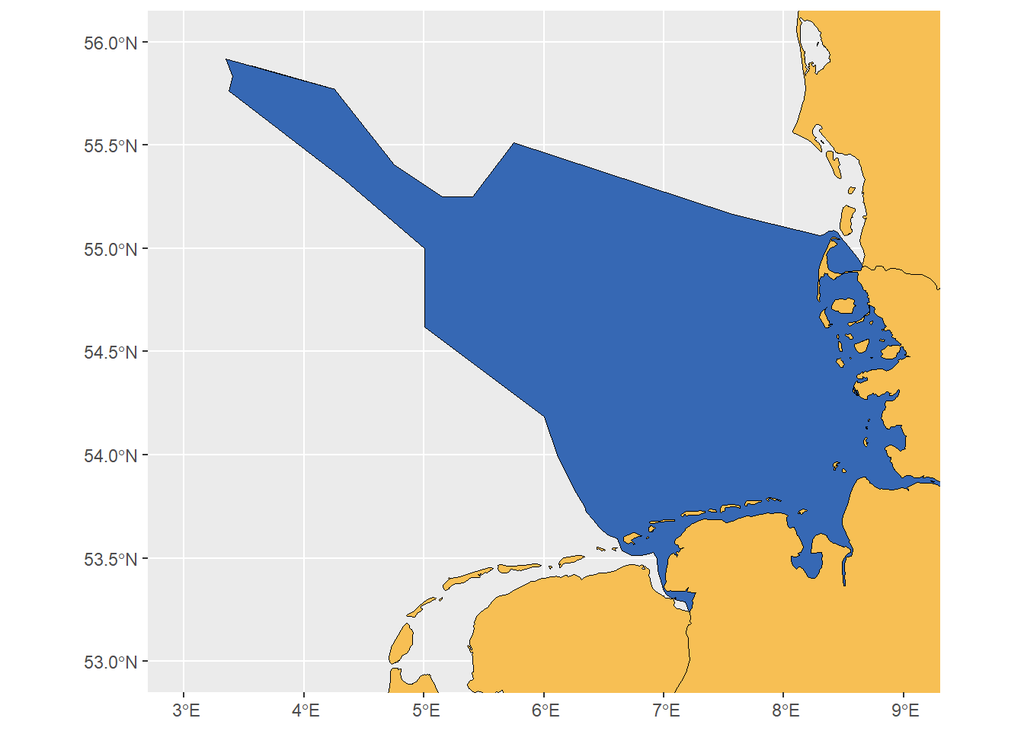

```r
base_plot<-ggplot2::ggplot()+
    # maps
    ggplot2::geom_sf(data = EEZ, colour = 'black', fill = color_water)+
    ggplot2::geom_sf(data = Europa, colour = 'black', fill = color_land)+
    ggplot2::coord_sf(xlim = xval, ylim = yval)+

    NULL
base_plot
```

## Add dots

Now add the density data on top of the base map.

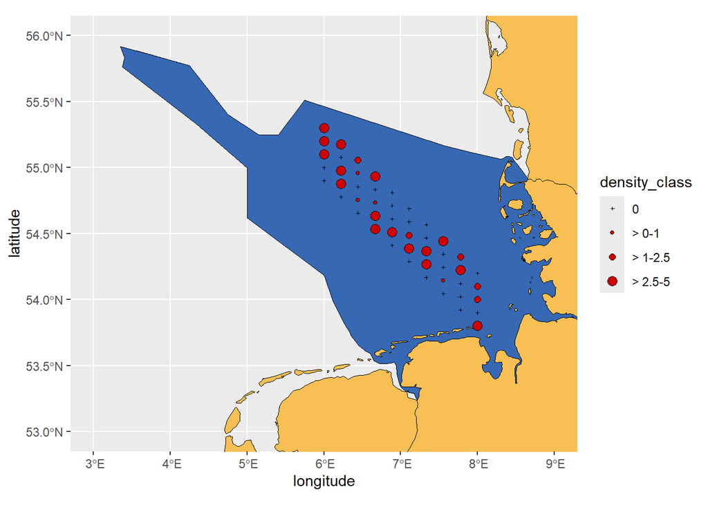

```r
density_wmap<-base_plot+
  geom_point(data=density_df,
          aes(x = longitude,
              y= latitude,
              shape = density_class,
              size= density_class),
              fill= "#d00000")+

  scale_shape_manual(values = density_shapes,labels=density_labels)+
  scale_size_manual(values =  density_sizes,labels=density_labels)
density_wmap
```

Now you have a base map with density information on different shape and size.

# Further reading

These figures are based on the SAS monitoring program, but note that data was randomly generated and do not correspond to real survey information.

See the real maps [here](https://www.researchgate.net/publication/366325582_Monitoring_von_Seevogeln_in_der_deutschen_Nord-_und_Ostsee_2021).

# ~~~~~~~~~~~~~

# 8.August: custom legend

# Intro

Customize the legend of your plot.

# Plot

```r
devtools::install_github("MiriamLL/SeaDens")
```

```r
library(SeaDens)
```

Load data

The package contains data from a random generated density data frame that can be used for the exercise.

If you want to create this map from scratch visit: [create a map with custom points](https://www.miriam-lerma.com/posts/2023-07-13-custompoints/).

```r
density_wmap<-density_wmap
```

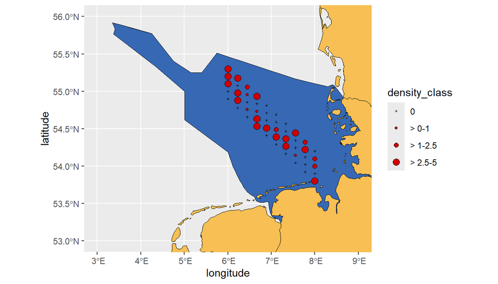

```r
density_wmap
```

## add_legend

I create this function to include the legend inside the plot, the function is available on the package **seamonas**.

The function removes the background of the legend making it transparent, and includes the legend inside the plot based on the coordinates provided.

```r
add_legend<-function(plot_wbreaks=plot_wbreaks,
                     legxy=legxy){
  plot_wlegend<-plot_wbreaks+
    ggplot2::theme(
      legend.position = legxy,
      legend.title = ggplot2::element_blank(),
      legend.text= ggplot2::element_text(size=10,color="#343a40",family='sans'),
      legend.spacing.y =  ggplot2::unit(0.01, 'cm'),
      legend.spacing.x =  ggplot2::unit(0.2, 'cm'),
      legend.background = ggplot2::element_rect(fill='transparent',colour ="transparent"),
      legend.box.background = ggplot2::element_rect(fill='transparent',colour ="transparent"),
      legend.key = ggplot2::element_rect(fill = "transparent", colour = "transparent"),
      legend.key.size =  ggplot2::unit(0.7, 'cm'))
  return(plot_wlegend)
}
```

Here, the arguments inside legxy are referring to where the legend will appear.

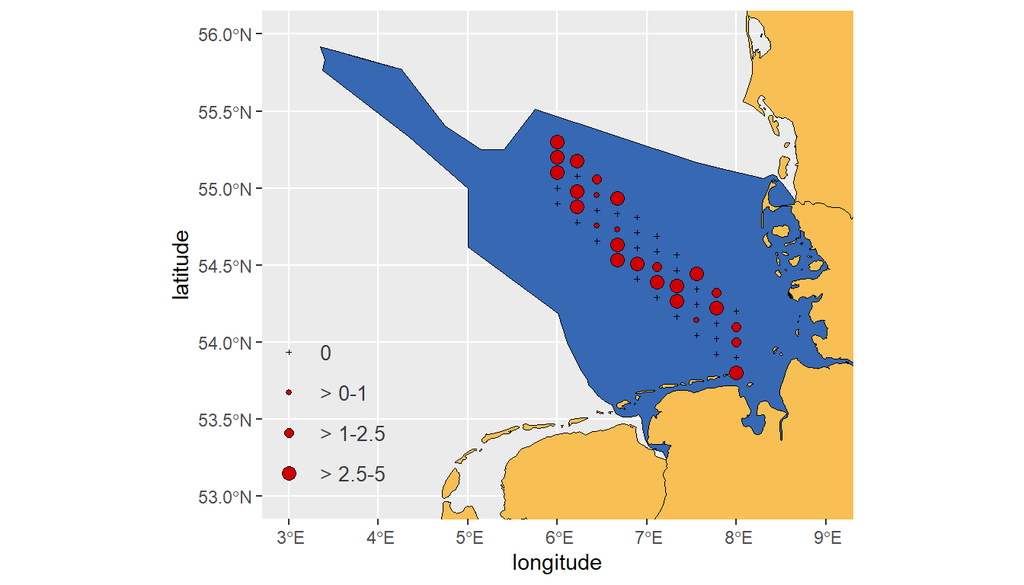

```r
density_wlegend<-add_legend(
  plot_wbreaks=density_wmap,
  legxy=c(0.11, 0.21))
density_wlegend
```

To add the title of the legend, I used the function annotate and a specific expression since I am using superscript.

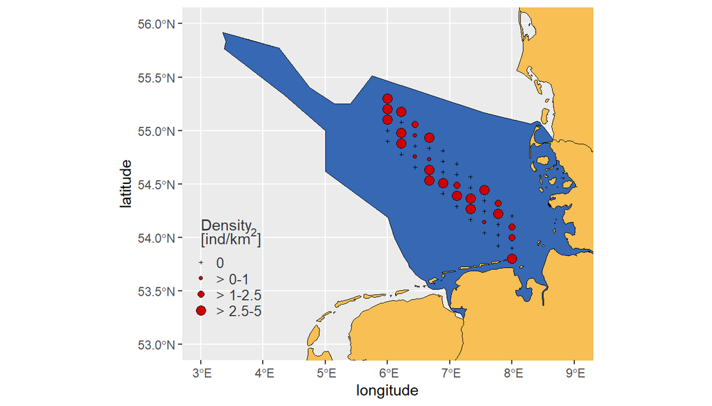

```r
density_wlegend<-density_wlegend+
  ggplot2::theme(legend.key.size = ggplot2::unit(0.4, "cm"))+
  ggplot2::annotate(geom="text",
                      x=3.0, y=54.0,
                      label=expression(atop("Density"), paste("[ind/k", m^2,"]")),
                      color="#343a40",hjust = 0)

density_wlegend
```

## add_theme

```r
add_theme<-function(plot_wlegend=plot_wlegend){

  plot_wtheme<-plot_wlegend+
    ggplot2::xlab('Longitude')+
    ggplot2::ylab('Latitude')+
    ggplot2::scale_x_continuous(labels = function(x) paste0(x, '\u00B0', "W")) +
    ggplot2::scale_y_continuous(labels = function(x) paste0(x, '\u00B0', "N"))+
    ggplot2::theme(
      panel.border = ggplot2::element_rect(colour = "black", fill=NA, linewidth = 1),
      panel.grid.major = ggplot2::element_blank(),
      panel.grid.minor = ggplot2::element_blank(),
      panel.background = ggplot2::element_blank())
  return(plot_wtheme)
}
```

To run the function just add your plot.

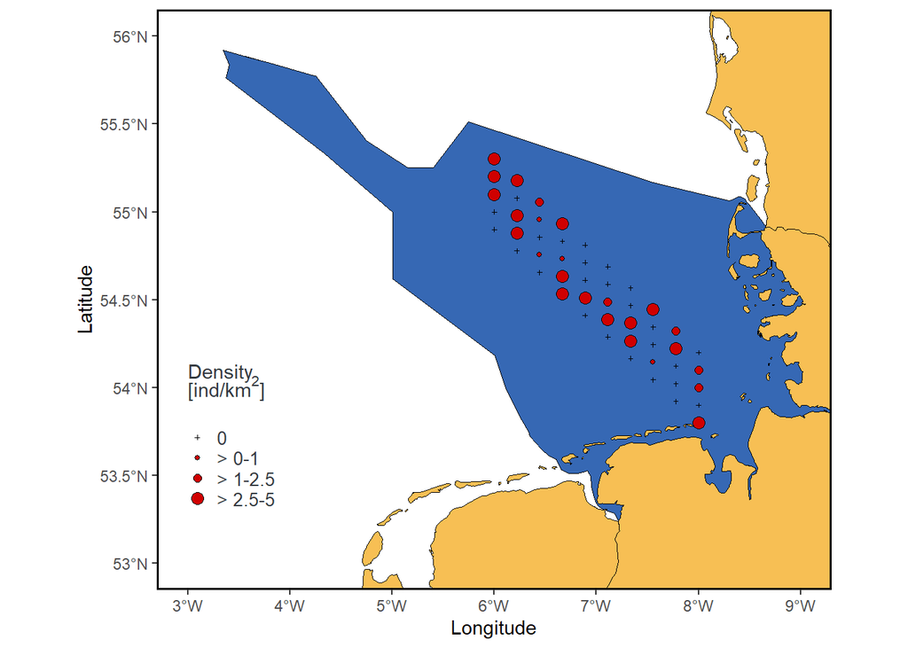

```r
density_wtheme<-add_theme(plot_wlegend = density_wlegend)
density_wtheme
```

You can theoretically use the function add_theme with any other map.

# Keep learning

- SeaDens
- [Plotting](https://miriamll.github.io/R_intro/Plotting_0606.html#56)

# Export

# ~~~~~~~~~~~~~

# 9.September: custom multiple legen

## Data

For this example, we will use the data provided in the package **sula**  
The data is from tracked masked boobies at Rapa Nui  
The data is already in tidy format

```r
my_data<-(sula::GPS_preparado)
```

## Grid

The steps on this parts are on “how to create [grid](https://www.miriam-lerma.com/posts/2023-04-06-gridraster/)”

Packages to use:

```r
library(tidyverse)
library(sf)
library(ggplot2)
```

Run to create a reference grid.

```r
my_points<-my_data %>%
  st_as_sf(coords=c('Longitude','Latitude'),
           crs=4326,
           remove=FALSE)

my_grid<-st_make_grid(my_points,
                       c(0.05, 0.05),
                       what = "polygons",
                       square = TRUE)

my_grid_sf = st_sf(my_grid) %>%
  mutate(grid_id = 1:length(lengths(my_grid)))

my_grid_sf$nlocs <- lengths(st_intersects(my_grid_sf,
                                          my_points))
```

For the exercices, we want to create plots per individual.

So lets first check the name of the individuals.

```r
unique(my_data$IDs)
```

```
##  [1] "GPS01" "GPS02" "GPS03" "GPS04" "GPS05" "GPS06" "GPS07" "GPS08" "GPS09"
## [10] "GPS10"
```

To count number of locations per grid and add it as a column in the original grid functions from the package **tidyverse** can be used.

```r
GPS01_subset<- my_data %>%
  filter(IDs=='GPS01')

GPS01_sf<-GPS01_subset %>%
  st_as_sf(coords=c('Longitude','Latitude'),
           crs=4326,
           remove=FALSE)

my_grid_sf$GPS01_nlocs<- lengths(st_intersects(my_grid_sf,
                                          GPS01_sf))
```

```r
GPS02_subset<- my_data %>%
  filter(IDs=='GPS02')

GPS02_sf<-GPS02_subset %>%
  st_as_sf(coords=c('Longitude','Latitude'),
           crs=4326,
           remove=FALSE)

my_grid_sf$GPS02_nlocs<- lengths(st_intersects(my_grid_sf,
                                          GPS02_sf))
```

# Plots

## Custom palette

Now to create a plot, lets select your palette based on the number of locations.

```r
range(my_grid_sf$GPS01_nlocs)
```

```
## [1]  0 16
```

```r
range(my_grid_sf$GPS02_nlocs)
```

```
## [1]  0 14
```

Because the palette is between 0 and 16, we will manually create the palette using characters.

```r
my_palette <- c("1" = "#FFCF70",
                "2" = "#FFC242",
                "3" = "#FFBE33",
                "4" = "#F5A300",
                "5" = "#FD9A21",
                "6" = "#FA8C02",
                "7" = "#FF740A",
                "8" = "#F56A00",
                "9" = "#CEA7EE",
                "10" = "#C698EB",
                "11" = "#B376E5",
                "12" = "#9D4EDD",
                "13" = "#9643DB",
                "14" = "#72369D",
                "15" = "#6E3498",
                "16" = "#3B194D")
```

To create the plot:  
1. Subset only to grids with data  
2. Convert the locations into character  
3. Add palette in scale_fill_manual  
4. Remove legend

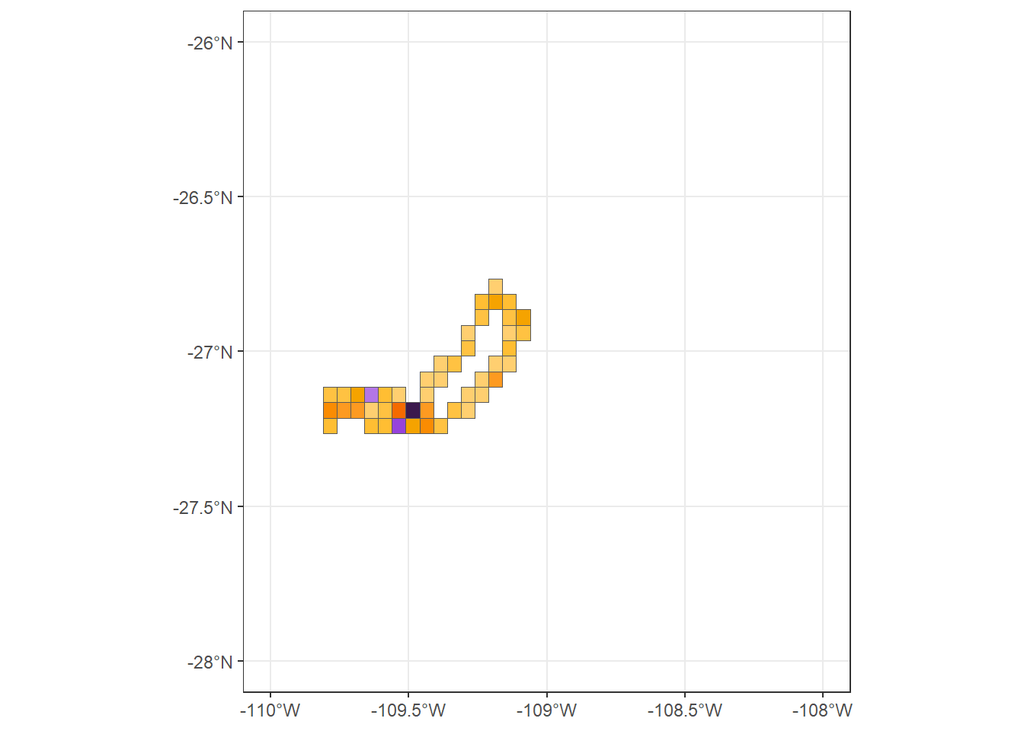

```r
GPS01_plot<-ggplot()+
  geom_sf(data=subset(my_grid_sf,GPS01_nlocs != 0),
                      aes(fill=as.character(GPS01_nlocs)))+
  theme_bw()+
  scale_fill_manual(name = "no.locs",values = my_palette)+
  theme(legend.position = 'none')+
  coord_sf(xlim = c(-110, -108),ylim = c(-28, -26))+
  scale_x_continuous(labels = function(x) paste0(x, '\u00B0', "W")) +
  scale_y_continuous(labels = function(x) paste0(x, '\u00B0', "N"))
GPS01_plot
```

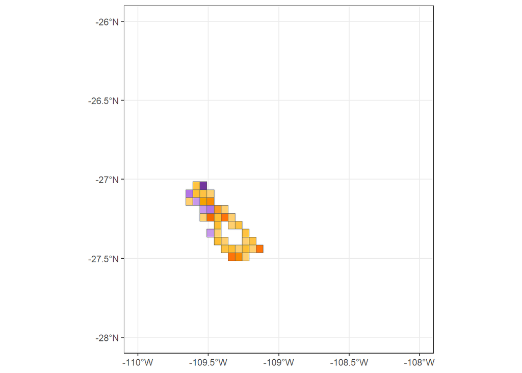

```r
GPS02_plot<-ggplot()+
  geom_sf(data=subset(my_grid_sf,GPS02_nlocs != 0),
                      aes(fill=as.character(GPS02_nlocs)))+
  theme_bw()+
  scale_fill_manual(name = "no.locs",values = my_palette)+
  theme(legend.position = 'none')+
  coord_sf(xlim = c(-110, -108),ylim = c(-28, -26))+
  scale_x_continuous(labels = function(x) paste0(x, '\u00B0', "W")) +
  scale_y_continuous(labels = function(x) paste0(x, '\u00B0', "N"))
GPS02_plot
```

# Legend

Now to create the legend, the information on the number of locations is also relevant as we will create a data frame with the number of locations and assign a color.

To create the data frame:

```r
this_legend <- data.frame(id = rep(1, 16), no.locations = 1:16)
```

To assign a color:

```r
my_legend_palette <- c(my_palette[[1]],
                          my_palette[[2]],
                          my_palette[[3]],
                          my_palette[[4]],
                          my_palette[[5]],
                          my_palette[[6]],
                          my_palette[[7]],
                          my_palette[[8]],
                          my_palette[[9]],
                          my_palette[[10]],
                          my_palette[[11]],
                          my_palette[[12]],
                          my_palette[[13]],
                          my_palette[[14]],
                          my_palette[[15]],
                          my_palette[[16]])
```

To create the plot, we will use the geometry **geom_tile**.

We can duplicate it just to make the plot thicker.

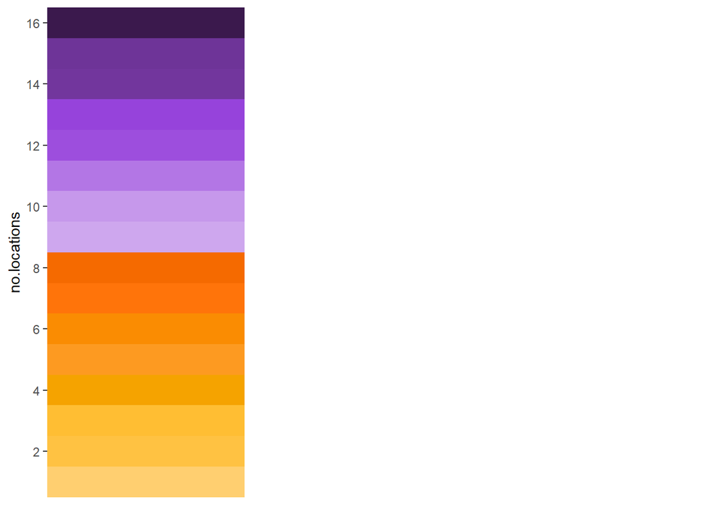

```r
plot_tracks_legend<-ggplot(this_legend) +
  geom_tile(aes(x = 0.5, y=no.locations, fill = as.factor(no.locations))) +
  geom_tile(aes(x = 1, y=no.locations, fill = as.factor(no.locations))) +
  scale_x_continuous(expand = c(0, 0),limits=c(0,5))+
  scale_y_continuous(name="no.locations",breaks=seq(0, 16, 2),expand = c(0, 0))+
  theme_bw()+
  scale_fill_manual(values=my_palette)+
  theme(legend.position='none',
        panel.grid.major = element_blank(),
        panel.grid.minor = element_blank(),
        panel.background = element_blank(),
        panel.border = element_blank(),
        axis.title.x = element_blank(),
        axis.text.x = element_blank(),
        axis.ticks.x = element_blank()
        )
plot_tracks_legend
```

# Patchwork

The package **patchwork** is very useful to create multiplots, a layout of several plots.

```r
library(patchwork)
```

The arguments to create our layout will include:  
- An empty plot (**plot_spacer**)  
- ncols is the number of columns  
- widths are the widths of each of the columns, here the plot is larger (5) and the legend thinner (1)  
- heights are to create equal height line of plots

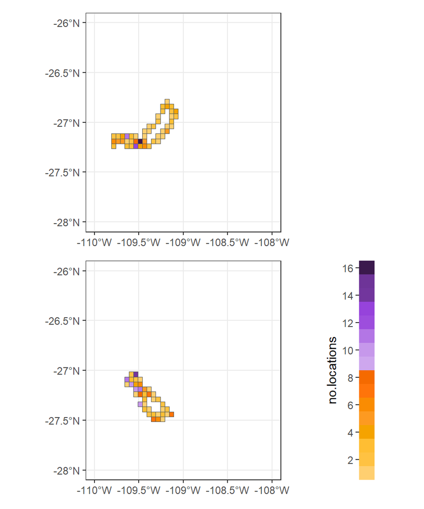

```r
(GPS01_plot+plot_spacer()+
   GPS02_plot+plot_tracks_legend)+
  plot_layout(ncol = 2,
              widths = c(5,1),
              heights=c(1,1))
```

Although you have the option of plot_layout(guides = “collect”) in the package **patchwork**. Sometimes not all plots have all the categories, and therefore it makes sense to create your own customize legend that fits all .

# Further reading

[Patchwork](https://patchwork.data-imaginist.com/)

# Export

# ~~~~~~~~~~~~~

# 10.October: inside legend

# Data

For this example, we will use the data provided in the package **sula**  
The data is from tracked masked boobies at Rapa Nui  
The data is already in tidy format

```r
my_data<-(sula::GPS_preparado)
```

```r
color1<-'#ff595e'
color2<-'#ff924c'
color3<-'#ffca3a'
color4<-'#8ac926'
color5<-'#52a675'
color6<-'#1982c4'
color7<-'#4267ac'
color8<-'#6a4c93'
```

# Plots

```r
library(ggplot2)
```

Lets create a plot where each color is a different individual and we gave specific colors.  
Note that this can also be made with scale_color_manual.  
However, for the example I separate them as you might be using layers.

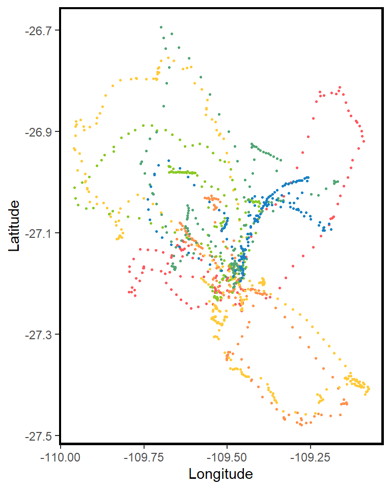

```r
my_plot<-ggplot() +

  geom_point(data = subset(my_data,IDs=='GPS01'),aes(x=Longitude,y=Latitude),color=color1,size=0.5,alpha=1)+
  geom_point(data = subset(my_data,IDs=='GPS02'),aes(x=Longitude,y=Latitude),color=color2,size=0.5,alpha=1)+
  geom_point(data = subset(my_data,IDs=='GPS03'),aes(x=Longitude,y=Latitude),color=color3,size=0.5,alpha=1)+
  geom_point(data = subset(my_data,IDs=='GPS04'),aes(x=Longitude,y=Latitude),color=color4,size=0.5,alpha=1)+
  geom_point(data = subset(my_data,IDs=='GPS05'),aes(x=Longitude,y=Latitude),color=color5,size=0.5,alpha=1)+
  geom_point(data = subset(my_data,IDs=='GPS06'),aes(x=Longitude,y=Latitude),color=color6,size=0.5,alpha=1)+

  theme(
  legend.position='none',
  legend.spacing.y = unit(0.05, 'cm'),
  legend.text=element_text(size=10),
  legend.background = element_rect(fill='transparent',colour ="transparent"),
  legend.box.background = element_rect(fill='transparent',colour ="transparent"),
  legend.key = element_rect(fill = "transparent", colour = "transparent"),
  panel.grid.major = element_blank(),
  panel.grid.minor = element_blank(),
  panel.background = element_blank())+
  xlab('Longitude')+ylab('Latitude')+
  theme(panel.border = element_rect(colour = "black", fill=NA, linewidth=1.5))
my_plot
```

## Inside legend

Select the coordinates for the legend

```r
legx<- -109.90
legy<- -27.4
```

Add text

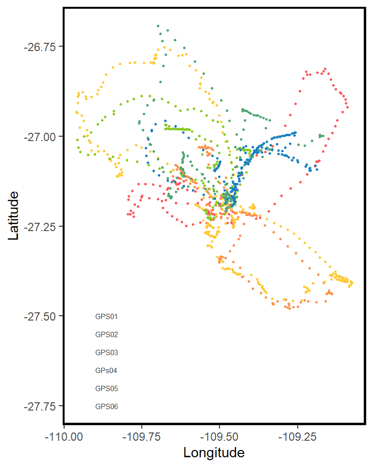

```r
my_plot_wtext<-my_plot +

  annotate(geom="text",x= legx, y=legy-0.1, label="GPS01",color="#343a40",hjust = 0, size=2)+
  annotate(geom="text",x= legx, y=legy-0.15, label="GPS02",color="#343a40",hjust = 0, size=2)+
  annotate(geom="text",x= legx, y=legy-0.2, label="GPS03",color="#343a40",hjust = 0, size=2)+
  annotate(geom="text",x= legx, y=legy-0.25, label="GPs04",color="#343a40",hjust = 0, size=2)+
  annotate(geom="text",x= legx, y=legy-0.3, label="GPS05",color="#343a40",hjust = 0, size=2)+
  annotate(geom="text",x= legx, y=legy-0.35, label="GPS06",color="#343a40",hjust = 0, size=2)
my_plot_wtext
```

Add segment

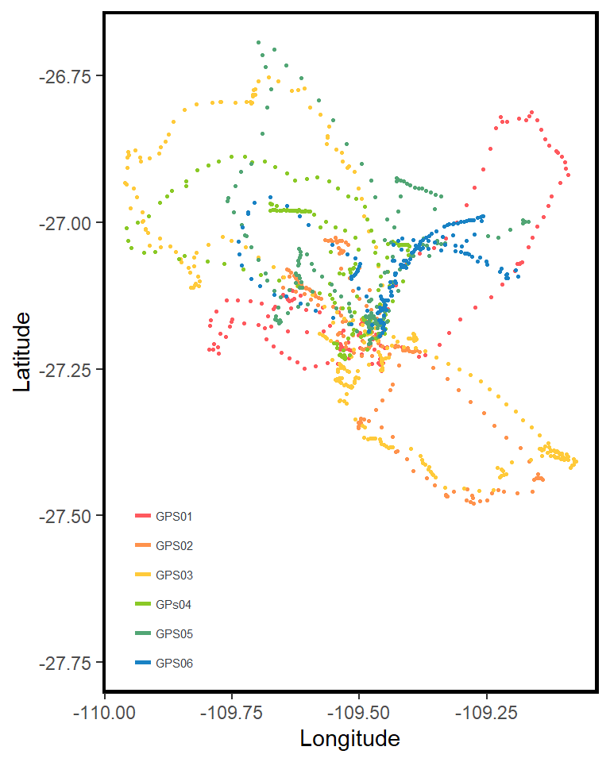

```r
my_plot_wtext +
  annotate("segment", x = legx-0.01, xend = legx-0.04, y = legy-0.1, yend = legy-0.1,color = color1,linewidth=1)+
  annotate("segment", x = legx-0.01, xend = legx-0.04, y = legy-0.15, yend = legy-0.15,color = color2,linewidth=1)+
  annotate("segment", x = legx-0.01, xend = legx-0.04, y = legy-0.2, yend = legy-0.2,color = color3,linewidth=1)+
  annotate("segment", x = legx-0.01, xend = legx-0.04, y = legy-0.25, yend = legy-0.25,color = color4,linewidth=1)+
  annotate("segment", x = legx-0.01, xend = legx-0.04, y = legy-0.3, yend = legy-0.3,color = color5,linewidth=1)+
  annotate("segment", x = legx-0.01, xend = legx-0.04, y = legy-0.35, yend = legy-0.35,color = color6,linewidth=1)
```

Add rectangle

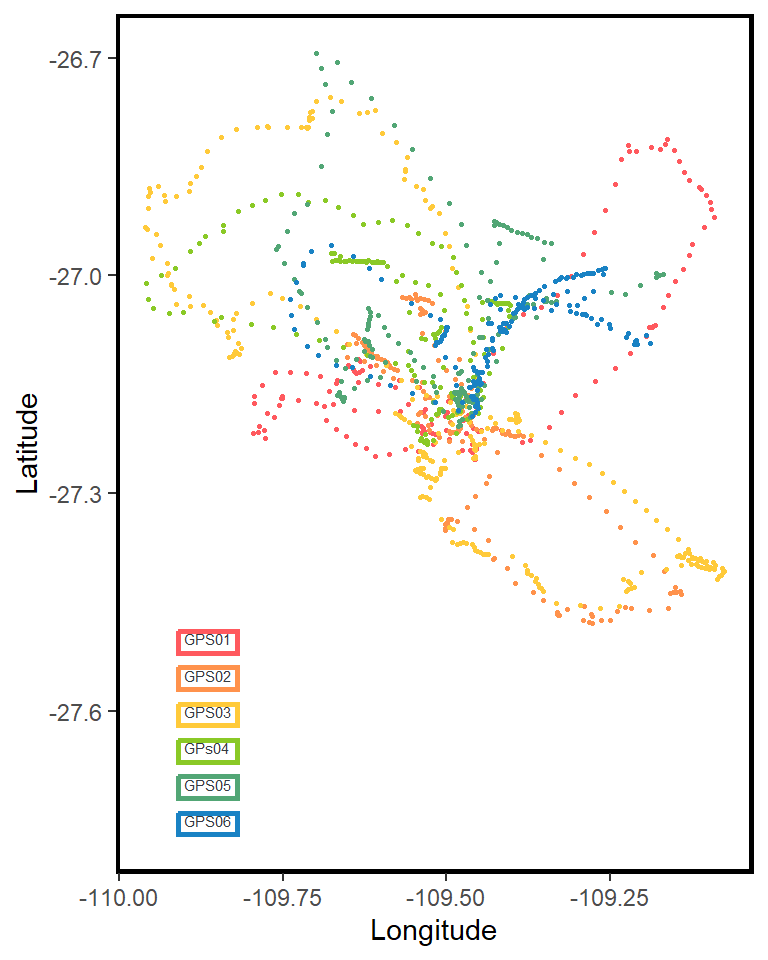

```r
my_plot_wtext +
  annotate("rect", xmin = legx-0.01, xmax = legx+0.08, ymin = legy-0.09, ymax = legy-0.12,color = color1,linewidth=1, fill="transparent")+
  annotate("rect", xmin = legx-0.01, xmax = legx+0.08, ymin = legy-0.14, ymax = legy-0.17,color = color2,linewidth=1, fill="transparent")+
  annotate("rect", xmin = legx-0.01, xmax = legx+0.08, ymin = legy-0.19, ymax = legy-0.22,color = color3,linewidth=1, fill="transparent")+
  annotate("rect", xmin = legx-0.01, xmax = legx+0.08, ymin = legy-0.24, ymax = legy-0.27,color = color4,linewidth=1, fill="transparent")+
  annotate("rect", xmin = legx-0.01, xmax = legx+0.08, ymin = legy-0.29, ymax = legy-0.32,color = color5,linewidth=1, fill="transparent")+
  annotate("rect", xmin = legx-0.01, xmax = legx+0.08, ymin = legy-0.34, ymax = legy-0.37,color = color6,linewidth=1, fill="transparent")
```

You can of course use the legend, but this option is for me more easy to custom and move around the plot. Moreover, it allows you to include all kinds of annotations inside the plot.

# Further reading

[Create an annotation layer](https://ggplot2.tidyverse.org/reference/annotate.html)

# Export

# ~~~~~~~~~~~~~

# 11.Novemeber: secondary axis title

This post is to show how to create a secondary x title in a ggplot

# Data

For this example we will create data.  
The data includes two species, two subsets and some values.

```r
my_data<-data.frame(my_species=c('a','a','a','a','a','b','b','b','b','b'),
                    my_subset=c('f','m','f','m','f','m','f','m','f','m'),
                    my_values=c(24,15,22,24,31,24,29,26,79,21)
                    )
```

Then, we will create a artificial grouping.

```r
my_data$my_groups<-paste(my_data$my_species,my_data$my_subset)
```

# Plot

Lets create a plot using ggplot.

```r
library(ggplot2)
```

Here, I use a geom_violin but the type of the plot is irrelevant for this exercise.  
Focus on the x axis.

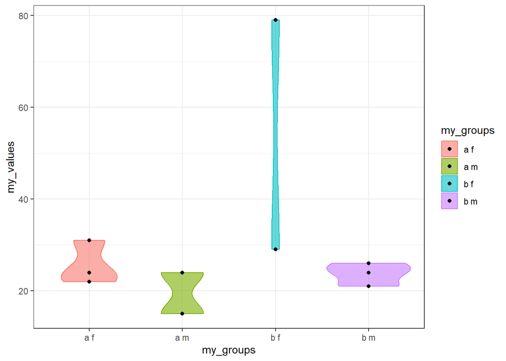

```r
plot_a<-ggplot(my_data, aes(y=my_values,x=my_groups, color=my_groups, fill=my_groups)) +
  geom_violin(alpha=0.6)+
  geom_point(color='black')+
  theme_bw()
plot_a
```

## Theme

Now lets remove the legend and the title of the x axis.  
Lets also replace the text in the x axis.

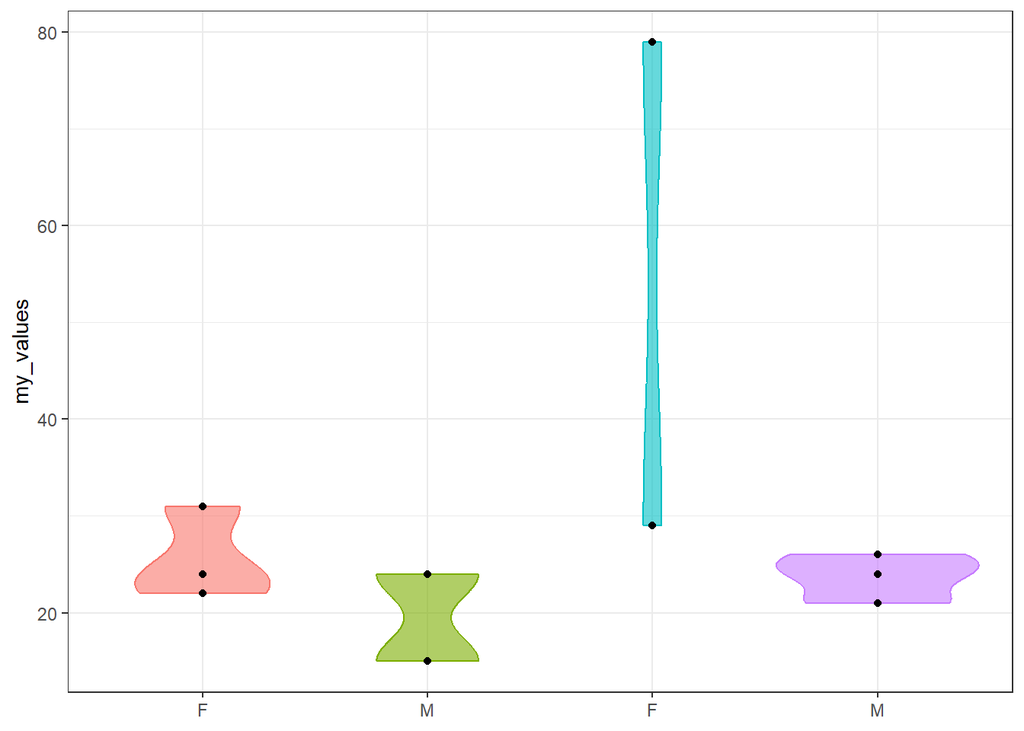

```r
plot_b<-plot_a+
  theme(legend.position = "none",
        axis.title.x = element_blank())+
  scale_x_discrete(labels=  c("F", "M", "F", "M"))
plot_b
```

## Increase coord

Now, the purpose of the exercise is to add a secondary axis.

To do this, we will expand the space on the y axis.

By doing so we will have more space for the secondary text. Note that it might be difficult to see at first grasp, but there is some empty space.

The arguments to increase the space are:  
- coord_cartesian and clip **off**  
- considering the y limit  
- change the plot.margin

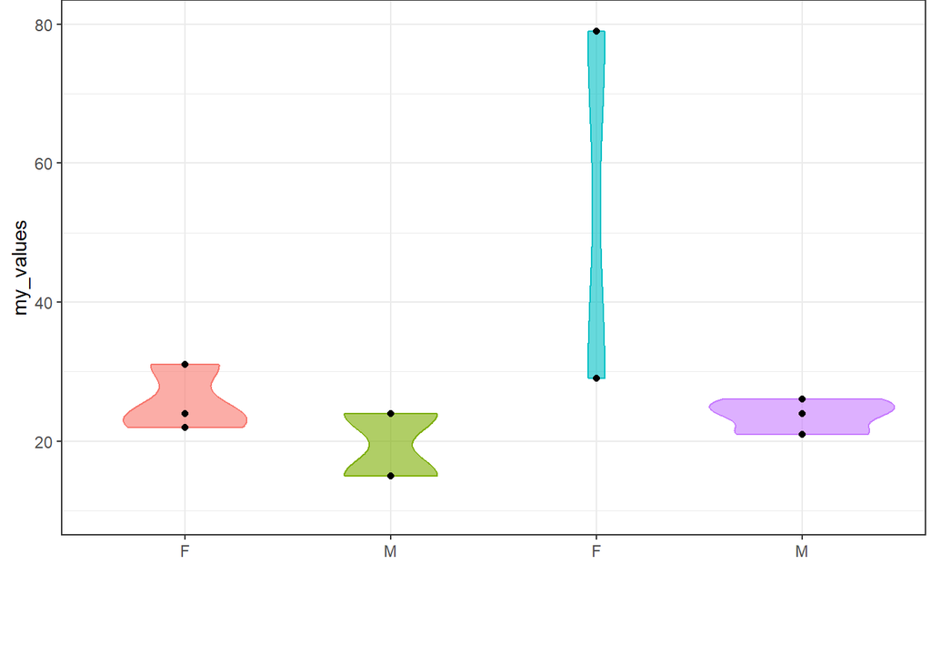

```r
plot_c<-plot_b+
  coord_cartesian(clip = "off",ylim = c(10, 80))+
  scale_y_continuous(breaks=c(20,40,60,80),
                     limits=c(-10,80))+
  theme(plot.margin=unit(c(0,0.1,2,0.2),"cm"))
plot_c
```

## Add segments and text

Now in the space created under the y axis, we can add the subtitles using the **annotation** arguments.

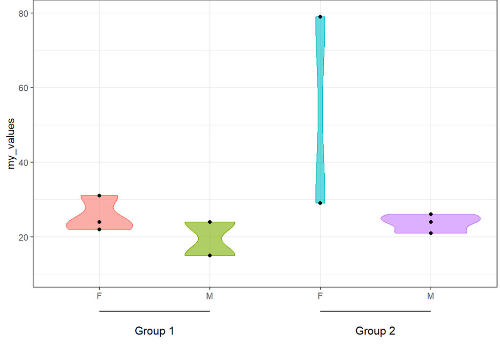

```r
plot_c+
  annotate(geom = "text",x = 1.5,y = -5, label = "Group 1",size = 4)+
  annotate("segment",y = 0, yend = 0,x = 1, xend = 2,colour = "black")+

  annotate(geom = "text",x = 3.5,y = -5, label = "Group 2",size = 4)+
  annotate("segment",y = 0, yend = 0,x = 3, xend = 4,colour = "black")
```

That was it, I hope it helps :)

# Export

# ~~~~~~~~~~~~~

# 12.December: arrows

This post is to create a plot that has arrows indicating the direction

In the example, we use sample data, but if you know where you event starts and ends you can skip these steps and go directly to the final section.

# Data

Load data from package **SeaDens**

```r
library(SeaDens)
```

This data is from a simulated survey

```r
survey_data<-survey_4326
```

## Calculate gaps

Using the information from time, we will check when there were gaps and based on where a gap was, identify different events

Load tidyverse package to use some functions

```r
library(tidyverse)
```

Check that your time data is in the correct format

```r
survey_data$dt <- as.POSIXct(strptime(survey_data$timestamps, "%Y-%m-%d %H:%M:%S"))
```

This function uses the times to identify where there was a gap, assuming that the data is sorted

```r
calculate_gaps<-function(my_data=my_data){
  time1<-my_data$dt
  time2<-lag(time1)
  time_dif<-as.numeric(difftime(time1,time2, units="mins"))
  my_data$time_dif<-as.numeric(time_dif)
  return(my_data)
}
```

After running the function, a new data frame will be created which includes a column named **time_dif**

```r
survey_data_gaps<-calculate_gaps(survey_data)
```

Here we will define, how many minutes should be considered a gap

```r
survey_data_gaps<-survey_data_gaps %>%
  mutate(gap_event = case_when(is.na(time_dif) ~ 'N',
                                time_dif >= 2 ~ 'Y',
                                TRUE ~ 'N'))
```

## Identify events

To add a number to each event in order to be able to identify them separately, we use the following function

```r
identify_events<-function(my_data=my_data){
  num_seq<-nrow(my_data)
  num_seq<-as.numeric(num_seq)
  my_data$num_seq<-as.numeric(paste(seq(1:num_seq)))
  subset_data<-subset(my_data,my_data$gap_event != "Y")
  subset_data$num_seq<-as.integer(subset_data$num_seq)
  subset_data$event_number<-(cumsum(c(1L, diff(subset_data$num_seq)) != 1L))
  subset_data$event_number<-subset_data$event_number+1
  subset_data$event_number<-stringr::str_pad(subset_data$event_number, 3, pad = "0")
  subset_data$event_number<-paste0("event_",subset_data$event_number)
  subset_data<-subset_data%>%select(num_seq,event_number)
  my_data_events<-full_join(my_data,subset_data,by='num_seq')
return(my_data_events)
}
```

The function will return a data frame with a new column called **event_number**

```r
survey_data_events<-identify_events(my_data=survey_data_gaps)
```

## Start and time of the events

Using the classification of the events, we will extract the first and the last location per event, which would become the start and end of the arrow on the plot

```r
survey_time_events<-survey_data_events %>%
  group_by(event_number)%>%
  summarise(first_lat=first(latitude),
            last_lat=last(latitude),
            first_lon=first(longitude),
            last_lon=last(longitude))%>%
  drop_na()
```

## Plot

To plot we use the function **geom_segment** and the additional argument **arrow**

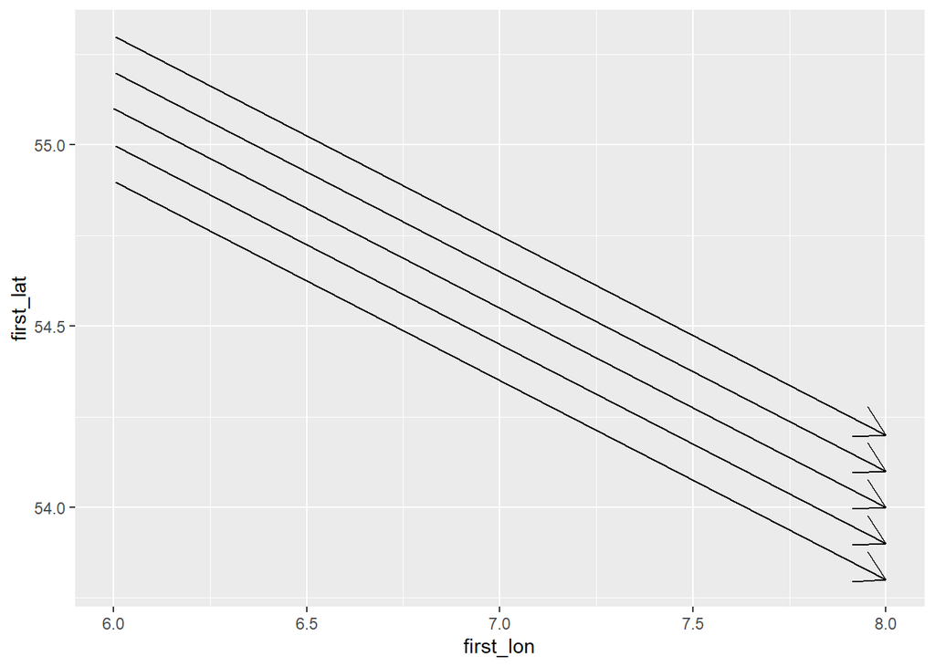

```r
ggplot(survey_time_events,
       aes(x = first_lon, y = first_lat)) +
  geom_segment(aes(xend = last_lon, yend = last_lat), arrow = arrow())
```

# Re-scale

If you were need more frequent arrows, you can re-scale the events

Here I create a for loop to re-scale separately per event

```r
rescale_events<-function(my_data=my_data,each_num=each_num){
  events_list<-split(my_data,my_data$event_number)
  new_events_list<-list()
  for( i in seq_along(events_list)){
    events_df<-events_list[[i]]
    rep_secuence<-rep(1:100, each=each_num)
    replicate_numbers<-rep_secuence[1:nrow(events_df)]
    events_df$rep_number<-replicate_numbers
    events_df$event_number2<-paste0(events_df$event_number,'-',events_df$rep_number)
    new_events_list[[i]]<-events_df
  }
new_events_df<- do.call("rbind",new_events_list)
return(new_events_df)
}
```

We define how often do we want the arrow to occur, here I selected 40, which represents the number of locations

```r
survey_rescale<-rescale_events(my_data=survey_data_events,each_num=40)
```

## Group by event

Use the function **group_by** and **summarise** to identify the start and end of the events, now with the rescaling there would be more events

```r
survey_rescale_arrows<-survey_rescale %>%
  group_by(event_number2)%>%
  summarise(first_lat=first(latitude),
            last_lat=last(latitude),
            first_lon=first(longitude),
            last_lon=last(longitude))%>%
  drop_na()
```

Similarly to above we use the function geom_segment and the argument arrow

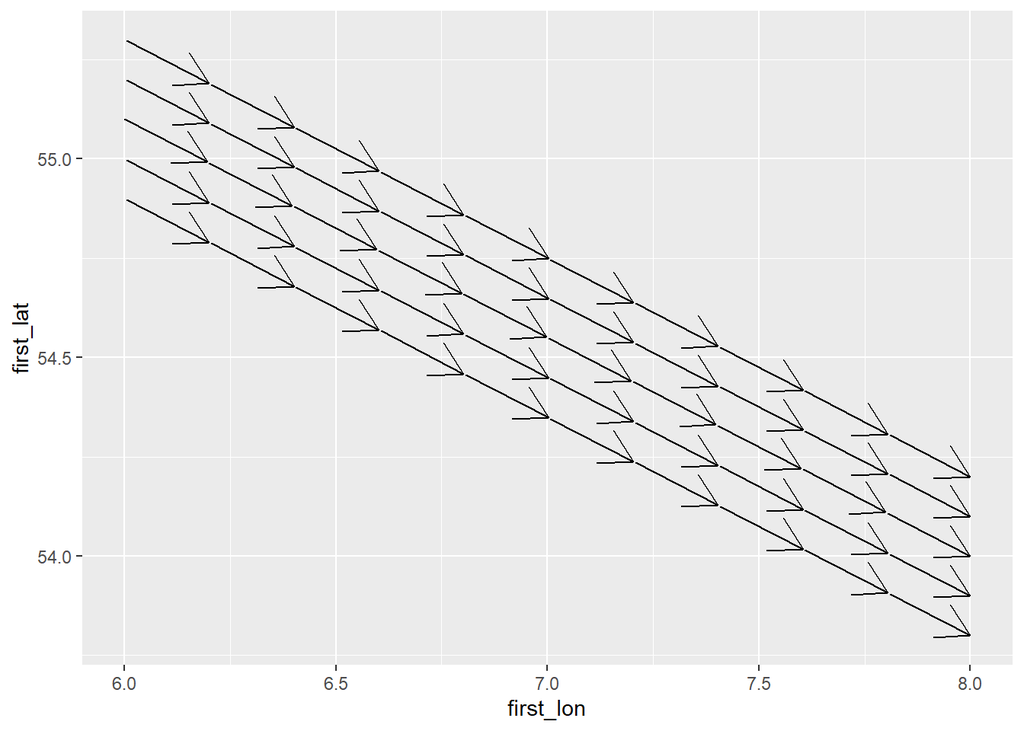

```r
ggplot(survey_rescale_arrows,
       aes(x = first_lon, y = first_lat)) +
  geom_segment(aes(xend = last_lon, yend = last_lat),
               arrow = arrow())
```

# In a map

Finally, to see how it would look in a map we will include a base map from Germany.

Load the shapefiles and the package to plot

```r
library(GermanNorthSea)
library(sf)
```

Transform to the corresponding CRS

```r
German_land<-st_transform(GermanNorthSea::German_land, 4326)
German_EEZ<-st_transform(GermanNorthSea::German_EEZ, 4326)
German_coast<-st_transform(GermanNorthSea::German_coast, 4326)
```

Add the corresponding arguments and voilà

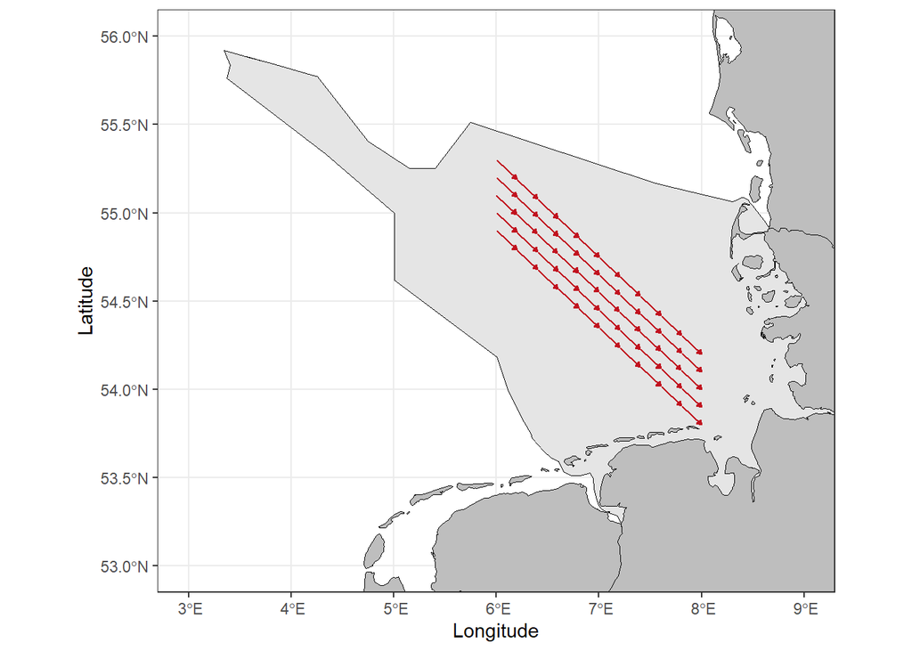

```r
ggplot() +
  geom_sf(data = German_EEZ, colour = 'black')+
  geom_sf(data = German_land, colour = 'black', fill = 'grey')+
  coord_sf(xlim = c(3, 9),ylim = c(53, 56))+
  theme_bw()+
  xlab('Longitude')+ylab('Latitude')+
  geom_segment(data=survey_rescale_arrows,aes(x = first_lon, y = first_lat,xend = last_lon, yend = last_lat),
               arrow = arrow(length=unit(0.10,"cm"), type = "closed"),
               color='#c1121f')
```

## Further reading

To change the shape, size and form of the arrow visit [geom_segment](https://ggplot2.tidyverse.org/reference/geom_segment.html)